# Análisis de Datos en Salud Mental, Estrés Económico y Siniestralidad Laboral

Explorando la intersección entre bienestar psicosocial y seguridad operativa

Nadina Díaz

14 abril 2026

## 1. Marco del Estudio

Se analiza la relación dinámica entre el **bienestar psicológico**, el **contexto económico** y la **siniestralidad laboral** registrada en Argentina **(2010–2024)**. Este estudio exploratorio busca identificar patrones y cambios estructurales en el tiempo, integrando variables que afectan la salud física y mental de los trabajadores bajo una perspectiva de salud ocupacional.

## 2. Objetivos

### 2.1 Objetivo general:

- Cuantificar la incidencia de factores psicosociales y variables económicas en la dinámica de la siniestralidad laboral registrada en Argentina (2010–2024)

### 2.2 Objetivos específicos:

- Establecer correlaciones estadísticas entre los niveles de malestar psicológico y la frecuencia de accidentes laborales, segmentando por género y rango etario.
- Determinar el impacto del estrés económico (inflación y pérdida de poder adquisitivo) sobre la seguridad operativa y el reporte de siniestros.
- Identificar quiebres de tendencia (breakpoints) en el comportamiento histórico de la serie, con especial énfasis en el período post-pandemia.

## 3. Hipótesis de Trabajo

Se plantean las siguientes hipótesis exploratorias:

- **Contexto Emocional:** A mayor malestar psicológico, se espera una mayor siniestralidad laboral.
- **Contexto Económico:** El aumento del estrés económico se asocia con mayores niveles de siniestralidad laboral.
- **Quiebre Estructural en Pandemia:** La pandemia de 2020 generó un cambio en la tendencia de la siniestralidad laboral.
- **Diferencias por Estratos:** La relación entre malestar psicológico y siniestralidad puede variar según características demográficas.

## 4. Fuentes de Datos Utilizadas

**Origen de los datos**

- **Superintendencia de Riesgos del Trabajo (SRT):** Series históricas de siniestralidad laboral .
- **Observatorio de la Deuda Social Argentina (UCA):** indicadores de malestar psicológico y estrés económico.
- **INDEC:** variables macroeconómicas.

**Variables principales analizadas**

- Siniestralidad laboral
- Malestar psicológico
- Estrés económico
- Inflación

**Limitaciones del dataset**

Los datos de siniestralidad laboral incluyen únicamente trabajadores cubiertos por ART, excluyendo aproximadamente un 40% de la población laboral sin cobertura.

Los indicadores de malestar psicológico provienen de la encuesta de la UCA, basada en una muestra de ~5.750 hogares en áreas metropolitanas, lo que puede limitar su representatividad a nivel nacional.

## 5. Metodología y Procesamiento de Datos

Con el fin de estandarizar métricas de distinta naturaleza y asegurar la robustez estadística del modelo, se implementaron técnicas de normalización, limpieza de anomalías (outliers) y segmentación por períodos

1. **Normalización (Z-Scores):** estandarización de variables para facilitar la comparación entre indicadores.
2. **Tratamiento de Anomalías (Outliers):** el año 2020 fue analizado como caso atípico debido al impacto de la pandemia.
3. **Segmentación Temporal:** en algunos análisis se dividió el período en pre-pandemia (2010–2019) y post-pandemia (2021–2024).
- **Herramientas:** procesamiento y visualización realizados en R (tidyverse y ggplot2).

## 6. Definición de Indicadores.

| Indicador | Descripción |
| --- | --- |
| **Tasa de Siniestralidad** | Eventos notificados cada 1.000 trabajadores cubiertos. |
| **Incidencia Global** | Casos con baja laboral o secuela cada 1.000 cubiertos. |
| **Malestar Psicológico** | Presencia de síntomas de ansiedad/depresión (Encuesta UCA). |
| **Estrés Económico** | Insuficiencia de ingresos percibida e incapacidad de ahorro. |
| **Inflación** | Aumento sostenido y generalizado de precios (IPC). |

## 7.Preparación de los Datos (Setting up)

### 7.1.Configuración del entorno

```r
library(tidyverse)   # Limpieza y manipulación (dplyr, ggplot2, tidyr)
library(lubridate)
library(knitr)
library(kableExtra)
library(readxl)
library(ggrepel)
```

### 7.2 Carga de Datasets

```r
df_salud_laboral <- read_excel("./data/Libro1.xlsx") #  Carga de dataset siniestralidad, malestar psicológico y datos económicos
```

**🔍Clic aquí para ver el resultado**

```r
df_salud_laboral %>%
  head(5) %>%
  kable(caption = "Primeros registros del dataset principal") %>%
  kable_styling(bootstrap_options = c("striped", "hover", "condensed", "responsive"))
```

Primeros registros del dataset principal

| Anio | Malestar_Total | Accidentabilidad_Laboral | Accid_un_dia_baja_mas | Trab_Activos | Estress_Econ | Inflacion |
| --- | --- | --- | --- | --- | --- | --- |
| 2010 | 18.4 | 630766 | 568162 | 7966922 | 38.9 | 25.7 |
| 2011 | 20.3 | 669088 | 609122 | 8311694 | 35.1 | 25.3 |
| 2012 | 19.6 | 661431 | 600808 | 8660094 | 38.1 | 26.5 |
| 2013 | 22.5 | 674963 | 612720 | 8770932 | 44.7 | 28.1 |
| 2014 | 21.4 | 660954 | 597718 | 9003968 | 47.5 | 41.7 |

```r
tabla_sexo <- read_excel("./data/Libro2.xlsx") #Datos Estratificados por sexo
```

**🔍Clic aquí para ver el resultado**

```r
head(tabla_sexo)%>%
  head(5) %>%
  kable(caption = "Primeros registros del dataset principal") %>%
  kable_styling(bootstrap_options = c("striped", "hover", "condensed", "responsive"))
```

Primeros registros del dataset principal

| Anio | Malestar_Muj | Malestar_homb | Inc_Global_Muj | Inc_global_Hom |
| --- | --- | --- | --- | --- |
| 2011 | 22.5 | 17.9 | 40.26186 | 90.92743 |
| 2012 | 22.7 | 16.1 | 40.78998 | 85.57885 |
| 2013 | 25.0 | 19.8 | 41.69421 | 85.30513 |
| 2014 | 24.4 | 17.8 | 40.01580 | 80.73799 |
| 2015 | 23.9 | 18.7 | 38.12790 | 77.45364 |

```r
df_edad <- read_excel("./data/Libro3.xlsx") #Datos Estratificados por edad
```

**🔍Clic aquí para ver el resultado**

```r
head(df_edad)%>%
  head(5) %>%
  kable(caption = "Primeros registros del dataset principal") %>%
  kable_styling(bootstrap_options = c("striped", "hover", "condensed", "responsive"))
```

Primeros registros del dataset principal

| Anio | Mpsic_18a34 | Mpsic_35a59 | Mpsic_60mas | CantSin_18a34 | CantSin_35a59 | CantSin_60mas |
| --- | --- | --- | --- | --- | --- | --- |
| 2016 | 16.2 | 23.5 | 26.8 | 279475 | 303554 | 24684 |
| 2017 | 15.5 | 21.2 | 21.5 | 265699 | 290988 | 23054 |
| 2018 | 19.2 | 23.0 | 19.1 | 247426 | 279265 | 21997 |
| 2019 | 21.0 | 24.1 | 21.0 | 239180 | 298443 | 24224 |
| 2020 | 25.4 | 25.4 | 21.3 | 162228 | 192610 | 10656 |

## 8. Análisis Exploratorio

### 8.1 Relación entre Malestar psicológico y siniestralidad laboral

Prepararamos la tabla de análisis y calculamos la correlación entre variables

```r
# Preparación de Tabla de Trabajo

df_analisis <- df_salud_laboral %>%
  mutate(
    tasa_siniestralidad = (Accidentabilidad_Laboral / Trab_Activos) * 1000,
  )

# Calculo de Correlación

cor_malestar <- cor(df_analisis$Malestar_Total, df_analisis$tasa_siniestralidad)
cor_malestar
```

```
## [1] -0.4248396
```

Graficamos las tendencias de malestar psicológico y tasa de siniestralidad laboral a lo largo de los años

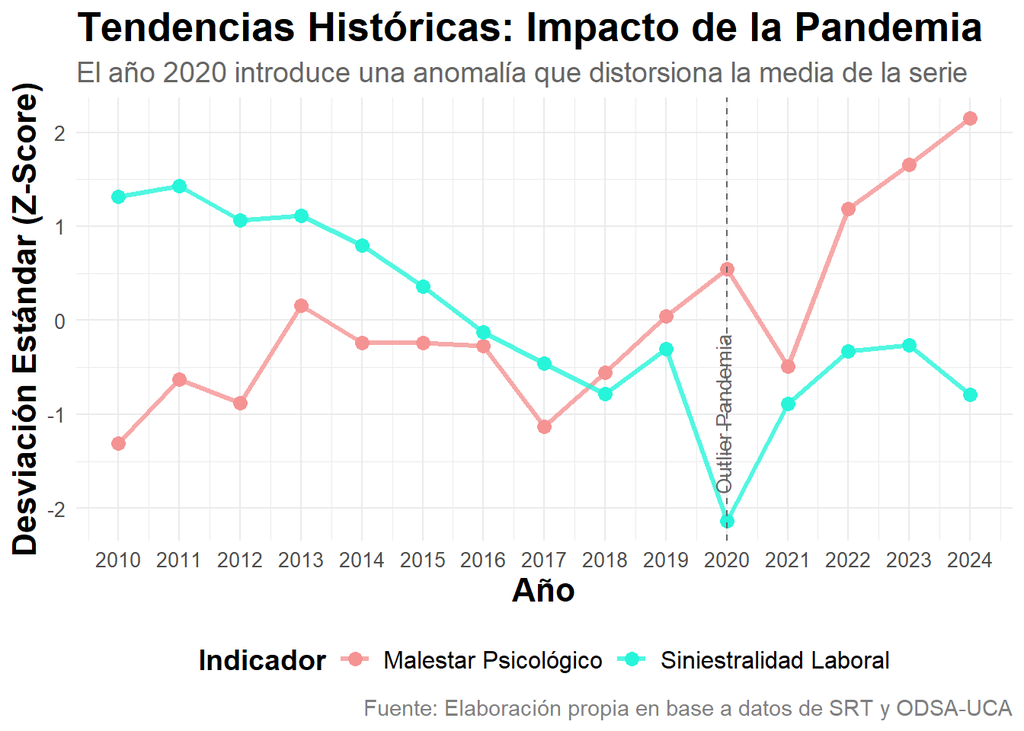

```r
# Definimos colores

colores_voro <- c("siniestralidad_z" = "#27F5DA", "malestar_z" = "#F59393")

# --- GRÁFICA 1: ESCENARIO TOTAL (CON 2020) ---

df_con_2020 <- df_analisis %>%
  select(Anio, Malestar_Total, tasa_siniestralidad) %>%
  mutate(
    malestar_z = (Malestar_Total - mean(Malestar_Total)) / sd(Malestar_Total),   # Normalización Z
    siniestralidad_z = (tasa_siniestralidad - mean(tasa_siniestralidad)) / sd(tasa_siniestralidad)  #Normalización Z
  ) %>%
  pivot_longer(cols = c(malestar_z, siniestralidad_z), names_to = "Variable", values_to = "Valor")

plot_con_2020 <- ggplot(df_con_2020, aes(x = Anio, y = Valor, color = Variable)) +
  geom_line(size = 1.2, alpha = 0.8) +
  geom_point(size = 3) +
  geom_vline(xintercept = 2020, linetype = "dashed", color = "gray40") +
  annotate("text", x = 2020.2, y = -1.0, label = "Outlier Pandemia",
           angle = 90, vjust = -0.5, color = "gray40", size = 3.5) +
  scale_x_continuous(breaks = 2010:2024) +
  scale_color_manual(values = colores_voro,
                     labels = c("Malestar Psicológico", "Siniestralidad Laboral")) +
  theme_minimal() +
  labs(title = "Tendencias Históricas: Impacto de la Pandemia",
       subtitle = "El año 2020 introduce una anomalía que distorsiona la media de la serie",
       caption = "Fuente: Elaboración propia en base a datos de SRT y ODSA-UCA",
       y = "Desviación Estándar (Z-Score)", x = "Año", color = "Indicador") +
  theme(
    legend.position = "bottom",

    # TÍTULO EXTRA GRANDE
    plot.title = element_text(size = 20, face = "bold", hjust = 0),

    # SUBTÍTULO MEDIANO
    plot.subtitle = element_text(size = 14, color = "gray40", hjust = 0),

    # EJES GRANDES
    axis.title = element_text(size = 16, face = "bold"),
    axis.text = element_text(size = 10),

    # LEYENDA GRANDE
    legend.title = element_text(size = 14, face = "bold"),
    legend.text = element_text(size = 12),

    # CAPTION
    plot.caption = element_text(size = 11, color = "gray50", hjust = 1)
  )
plot_con_2020
```

La **pandemia** introduce un cambio en la dinámica: disminuyen los accidentes mientras aumenta el malestar. Este desacople puede estar asociado a cambios en la modalidad de trabajo (teletrabajo), que redujeron la exposición a riesgos físicos sin mejorar el bienestar psicológico.

Si eliminamos el año 2020 por ser un outlier estructural:

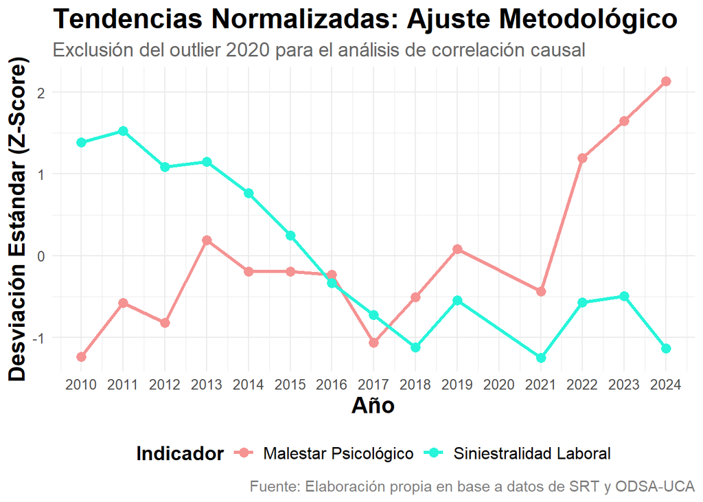

```r
# --- GRÁFICA 2: ESCENARIO FILTRADO (SIN 2020) ---
df_sin_2020 <- df_analisis %>%
  filter(Anio != 2020) %>%
  select(Anio, Malestar_Total, tasa_siniestralidad) %>%
  mutate(
    malestar_z = (Malestar_Total - mean(Malestar_Total)) / sd(Malestar_Total), #Normalización Z
    siniestralidad_z = (tasa_siniestralidad - mean(tasa_siniestralidad)) / sd(tasa_siniestralidad) #Normalización Z
  ) %>%
  pivot_longer(cols = c(malestar_z, siniestralidad_z), names_to = "Variable", values_to = "Valor")

plot_sin_2020 <- ggplot(df_sin_2020, aes(x = Anio, y = Valor, color = Variable)) +
  geom_line(size = 1.2) +
  geom_point(size = 3) +
  # Dejamos el hueco en 2020 para honestidad visual
  scale_x_continuous(breaks = 2010:2024) +
  scale_color_manual(values = colores_voro,
                     labels = c("Malestar Psicológico", "Siniestralidad Laboral")) +
  theme_minimal() +
  labs(title = "Tendencias Normalizadas: Ajuste Metodológico",
       subtitle = "Exclusión del outlier 2020 para el análisis de correlación causal",
       caption = "Fuente: Elaboración propia en base a datos de SRT y ODSA-UCA",
       y = "Desviación Estándar (Z-Score)", x = "Año", color = "Indicador") +
  theme(
    legend.position = "bottom",

    # TÍTULO EXTRA GRANDE
    plot.title = element_text(size = 20, face = "bold", hjust = 0),

    # SUBTÍTULO MEDIANO
    plot.subtitle = element_text(size = 14, color = "gray40", hjust = 0),

    # EJES GRANDES
    axis.title = element_text(size = 16, face = "bold"),
    axis.text = element_text(size = 10),

    # LEYENDA GRANDE
    legend.title = element_text(size = 14, face = "bold"),
    legend.text = element_text(size = 12),

    # CAPTION
    plot.caption = element_text(size = 11, color = "gray50", hjust = 1)
  )
# Visualizar
print(plot_sin_2020)
```

Calulamos las correlaciones pre y post pandemia

```r
## Correlaciones
# Pre pandemia

cor_prepan <- cor(df_analisis %>% filter(Anio <= 2019) %>% pull(Malestar_Total),
                  df_analisis %>% filter(Anio <= 2019) %>% pull(tasa_siniestralidad),
                  use = "complete.obs")
cor_prepan
```

```
## [1] -0.1285704
```

```r
# Post pandemia
cor_postpan <- cor(df_analisis %>% filter(Anio >= 2021) %>% pull(Malestar_Total),
                   df_analisis %>% filter(Anio >= 2021) %>% pull(tasa_siniestralidad),
                   use = "complete.obs")
cor_postpan
```

```
## [1] 0.4228522
```

[figure not shown]

```r
ggplot(df_analisis, aes(x = Malestar_Total, y = tasa_siniestralidad, color = Anio >= 2021)) +

  # Puntos con transparencia (alpha)
  geom_point(size = 4, alpha = 0.7) +

  # Líneas de tendencia un poco más gruesas

  geom_smooth(method = "lm", se = FALSE, size = 1.2) +

  # ANOTACIONES DE CORRELACIÓN

  annotate("label", x = 19, y = 78,
           label = paste0("Corr. Pre: ", round(cor_prepan, 2)),
           color = "#1DA190", fontface = "bold", fill = "white", label.size = 0.5) +
  annotate("label", x = 27, y = 45,
           label = paste0("Corr. Post: ", round(cor_postpan, 2)),
           color = "#D46A6A", fontface = "bold", fill = "white", label.size = 0.5) +

  # Colores
  scale_color_manual(values = c("FALSE" = "#27F5DA", "TRUE" = "#F59393"),
                     labels = c("Pre-Pandemia (2010-2019)", "Post-Pandemia (2021-2024)")) +

  # Etiquetas claras
  labs(title = "El Quiebre Estructural de la Siniestralidad",
       subtitle = "De una relación inexistente a una correlación positiva tras la crisis sanitaria",
       x = "Malestar Psicológico (%)",
       y = "Tasa de Siniestralidad (por cada 1000 trab.)",
       color = "Periodo Histórico",
       caption = "Fuente: Elaboración propia en base a datos de SRT y ODSA-UCA") +

  # MEJORAS DE TEMA
  theme_minimal(base_size = 13) +
  theme(
    plot.title = element_text(face = "bold", size = 20),
    plot.subtitle = element_text(color = "gray30", size=14),
    legend.position = "bottom",
    legend.background = element_rect(fill = "gray98", color = NA),
    panel.grid.minor = element_blank(), # Limpiamos ruido visual,
    axis.title = element_text(size = 16, face = "bold"),
    axis.text = element_text(size = 12),

    legend.title = element_text(size = 10, face = "bold"),
    legend.text = element_text(size = 8),

    plot.caption = element_text(size = 11, color = "gray50", hjust = 1)
  )
```

**Evidencia de Inestabilidad Temporal**

- **2010–2019:** Correlación nula (-0.13), indicando independencia entre las variables.
- **2021–2024:** Correlación positiva moderada (0.42). Los niveles elevados de malestar psicológico comienzan a asociarse con mayores tasas de siniestralidad.

**Conclusión:** Las transformaciones económicas y laborales recientes sugieren que el malestar psicológico ha ganado relevancia como factor de riesgo laboral.

### 8.2 El ciclo económico y la exposición al riesgo

**Desconexión entre Inflación y Siniestralidad**

- **Ausencia de Predictor Directo:** Si bien existen periodos de coincidencia, no se observa una relación consistente a largo plazo. El aumento crítico de la inflación en los últimos años no se ha traducido en un incremento de la siniestralidad.
- **Factores Determinantes:** La siniestralidad laboral parece responder más a factores estructurales y de exposición al riesgo que a variables macroeconómicas de corto plazo.

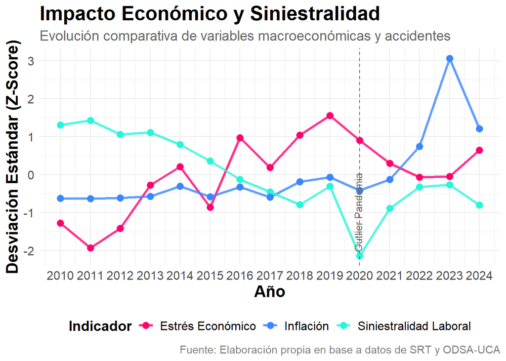

```r
# --- GRÁFICA: ESCENARIO TOTAL ECONÓMICOS (CON 2020) ---

# Definimos una paleta de 3 colores para esta sección
colores_econ <- c("siniestralidad_z" = "#27F5DA",
                  "inflacion_z" = "#3A86FF",
                  "estres_econ_z" = "#FF006E")

df_econ_2020 <- df_analisis %>%

  # Normalización de variables
  select(Anio, Estress_Econ, tasa_siniestralidad, Inflacion) %>%
  mutate(
    siniestralidad_z = (tasa_siniestralidad - mean(tasa_siniestralidad)) / sd(tasa_siniestralidad),
    inflacion_z = (Inflacion - mean(Inflacion)) / sd(Inflacion),
    estres_econ_z = (Estress_Econ - mean(Estress_Econ)) / sd(Estress_Econ)
  ) %>%
  pivot_longer(cols = c(siniestralidad_z, inflacion_z, estres_econ_z),
               names_to = "Variable",
               values_to = "Valor")

#Gráfico

ggplot(df_econ_2020, aes(x = Anio, y = Valor, color = Variable)) +
  geom_line(size = 1.2, alpha = 0.8) +
  geom_point(size = 3) +
  geom_vline(xintercept = 2020, linetype = "dashed", color = "gray40") +
  annotate("text", x = 2020.2, y = -1, label = "Outlier Pandemia",
           angle = 90, vjust = -0.5, color = "gray40", size = 3.5) +
  scale_x_continuous(breaks = 2010:2024) +
  # ACTUALIZADO: Etiquetas para las 3 variables
  scale_color_manual(values = colores_econ,
                     labels = c("Estrés Económico", "Inflación", "Siniestralidad Laboral")) +
  theme_minimal() +
  labs(title = "Impacto Económico y Siniestralidad",
       subtitle = "Evolución comparativa de variables macroeconómicas y accidentes",
       caption = "Fuente: Elaboración propia en base a datos de SRT y ODSA-UCA",
       y = "Desviación Estándar (Z-Score)",
       x = "Año",
       color = "Indicador") +
  theme(
    legend.position = "bottom",

    # TÍTULO EXTRA GRANDE
    plot.title = element_text(size = 20, face = "bold", hjust = 0),

    # SUBTÍTULO MEDIANO
    plot.subtitle = element_text(size = 14, color = "gray40", hjust = 0),

    # EJES GRANDES
    axis.title = element_text(size = 16, face = "bold"),
    axis.text = element_text(size = 12),

    # LEYENDA GRANDE
    legend.title = element_text(size = 14, face = "bold"),
    legend.text = element_text(size = 12),

    # CAPTION
    plot.caption = element_text(size = 11, color = "gray50", hjust = 1)
  )
```

Si analizamos más a fondo la relación entre la siniestralidad laboral y el estrés económico encontramos una relación inversa

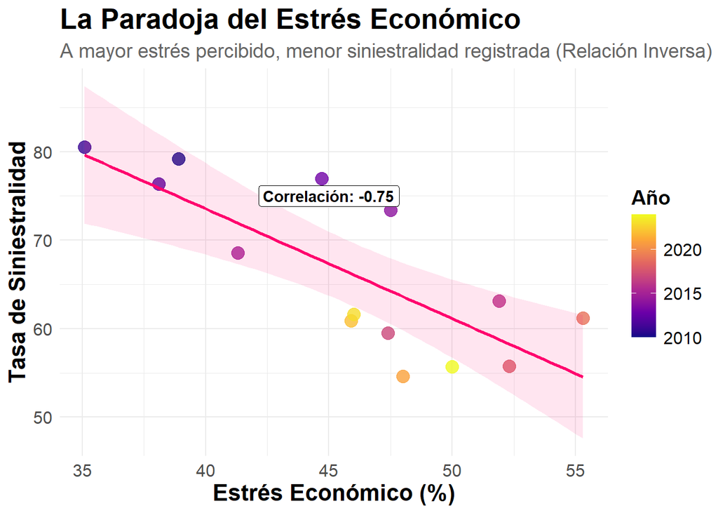

```r
# Calculamos la correlación para la etiqueta
cor_val <- cor(df_analisis$Estress_Econ, df_analisis$tasa_siniestralidad, use="complete.obs")

ggplot(df_analisis %>% filter(Anio != 2020), aes(x = Estress_Econ, y = tasa_siniestralidad)) +
  geom_point(aes(color = Anio), size = 4, alpha = 0.8) +
  # Añadimos la línea de regresión para ver la "dirección" de la relación
  geom_smooth(method = "lm", color = "#FF006E", fill = "#FF006E", alpha = 0.1) +
  # Coloreamos los puntos por año para ver la evolución temporal
  scale_color_viridis_c(option = "plasma") +
  annotate("label", x = 45, y = 75,
           label = paste0("Correlación: ", round(cor_val, 2)),
           fill = "white", fontface = "bold") +
  theme_minimal() +
  labs(title = "La Paradoja del Estrés Económico",
       subtitle = "A mayor estrés percibido, menor siniestralidad registrada (Relación Inversa)",
       x = "Estrés Económico (%)",
       y = "Tasa de Siniestralidad",
       color = "Año") +
  theme(

    # TÍTULO EXTRA GRANDE
    plot.title = element_text(size = 20, face = "bold", hjust = 0),

    # SUBTÍTULO MEDIANO
    plot.subtitle = element_text(size = 14, color = "gray40", hjust = 0),

    # EJES GRANDES
    axis.title = element_text(size = 16, face = "bold"),
    axis.text = element_text(size = 12),

    # LEYENDA GRANDE
    legend.title = element_text(size = 14, face = "bold"),
    legend.text = element_text(size = 12),
  )
```

**Estrés económico y siniestralidad: relación inversa**

- **Correlación Negativa Fuerte (-0.75):** A medida que aumenta la percepción de insuficiencia de ingresos, la siniestralidad registrada desciende de manera pronunciada.
- **Efecto de la Actividad Económica:** Este fenómeno no indica una mejora en la seguridad, sino que sugiere una reducción en la exposición al riesgo debido a la caída de la actividad económica y el empleo durante las crisis.
- **Subnotificación por Precariedad:** El estrés económico puede actuar como una barrera para la denuncia de siniestros, donde el temor a la inestabilidad laboral prevalece sobre el reporte de accidentes menores.

Si analizamos las correlaciones entre cantidad de siniestros denunciados y las edades de los trabajadores encontramos una diversidad por rango etario

```r
 # Correlación Grupo 18-34
  cor_jovenes <- cor(df_edad$Mpsic_18a34, df_edad$CantSin_18a34, use="complete.obs")

  # Correlación Grupo 35-59
  cor_adultos <- cor(df_edad$Mpsic_35a59, df_edad$CantSin_35a59, use="complete.obs")

  # Correlación Grupo 60+
  cor_mayores <- cor(df_edad$Mpsic_60mas, df_edad$CantSin_60mas, use="complete.obs")

  # Resultados
  print(paste("Corr. Jóvenes (18-34):", round(cor_jovenes, 3)))
```

```
## [1] "Corr. Jóvenes (18-34): -0.715"
```

```r
  print(paste("Corr. Adultos (35-59):", round(cor_adultos, 3)))
```

```
## [1] "Corr. Adultos (35-59): 0.36"
```

```r
  print(paste("Corr. Mayores (60+):", round(cor_mayores, 3)))
```

```
## [1] "Corr. Mayores (60+): -0.045"
```

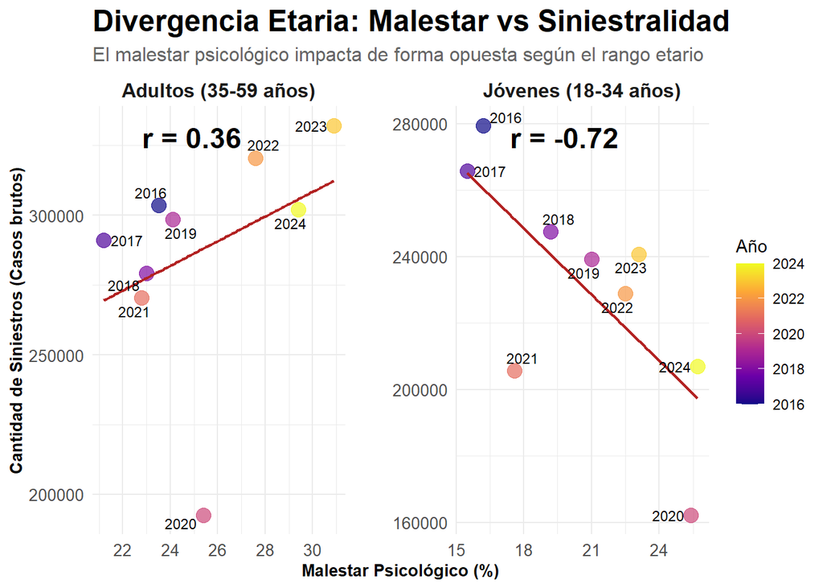

```r
 # 1. Creamos el dataframe de etiquetas con posiciones relativas

  cor_labels <- data.frame(
    Grupo = c("Jóvenes (18-34 años)", "Adultos (35-59 años)"),
    x = c(-Inf, -Inf),
    y = c(Inf, Inf),
    label = c(
      paste0("r = ", round(cor_jovenes, 2)),
      paste0("r = ", round(cor_adultos, 2))
    ),
    # Aquí definimos un ajuste distinto para cada uno si hace falta
    ajuste_h = c(-0.5, -0.5) # Probá con 1.2 o 1.5 para alejarlos del borde
  )


  # Armado de tabla
  df_jovenes <- df_edad %>%
    select(Anio, Malestar = Mpsic_18a34, Siniestralidad = CantSin_18a34) %>%
    mutate(Grupo = "Jóvenes (18-34 años)")

  df_adultos <- df_edad %>%
    select(Anio, Malestar = Mpsic_35a59, Siniestralidad = CantSin_35a59) %>%
    mutate(Grupo = "Adultos (35-59 años)")

  df_scatter_edad <- bind_rows(df_jovenes, df_adultos)

  df_scatter_edad <- df_scatter_edad %>%
    filter(!is.na(Malestar) & !is.na(Siniestralidad))


  ggplot(df_scatter_edad, aes(x = Malestar, y = Siniestralidad)) +
    geom_point(aes(color = Anio), size = 4, alpha = 0.7) +
    geom_smooth(method = "lm", color = "firebrick", se = FALSE, size = 0.8) +

    # Usamos ggrepel solo para los años

    geom_text_repel(aes(label = Anio), size = 3, segment.alpha = 0.3) +

    # 2. Correlación posicionada en la esquina superior izquierda
    geom_text(
      data = cor_labels,
      aes(x = x, y = y, label = label, hjust = ajuste_h),
      inherit.aes = FALSE,
      vjust = 2,
      size = 6,
      fontface = "bold",
      color = "black"
    ) +

    scale_color_viridis_c(option = "plasma") +
    facet_wrap(~Grupo, scales = "free") +
    theme_minimal() +
    labs(
      title = "Divergencia Etaria: Malestar vs Siniestralidad",
      subtitle = "El malestar psicológico impacta de forma opuesta según el rango etario",
      x = "Malestar Psicológico (%)",
      y = "Cantidad de Siniestros (Casos brutos)",
      color = "Año"
    ) +
    theme(
      strip.text = element_text(face = "bold", size = 12),
      panel.spacing = unit(2, "lines"),      # Damos más espacio entre los dos cuadros

      plot.title = element_text(size = 18, face = "bold", hjust = 0),

      plot.subtitle = element_text(size = 12, color = "gray40", hjust = 0),  # También izquierda

      axis.title = element_text(size = 10, face = "bold"),
      axis.text = element_text(size = 10),
    )
```

**Divergencia por Rangos Etarios**

- **Adultos (35-59 años):** Correlación positiva moderada (r=0.36), el incremento del malestar psicológico se asocia con un aumento en la siniestralidad registrada.
- **Jóvenes (18-34 años):** Fuerte correlación inversa (r=−0.72), sugiriendo una subnotificación crítica por precariedad o rotación laboral.

## 9. Conclusiones

**💡 Madurez de los Sistemas de Gestión:** La implementación de protocolos estrictos durante la crisis sanitaria (2020-2021) generó una mejora residual en la cultura preventiva. Esto ha permitido mantener tasas de accidentes bajas, a pesar del deterioro sostenido del entorno macroeconómico y social.

## 10.Propuestas y líneas de acción.

Para transformar estos hallazgos en mejoras operativas, se proponen las siguientes intervenciones:

**1. Vigilancia integral de riesgos**

- Integrar salud mental en controles médicos para detección temprana de riesgo.
- Protocolos para teletrabajo, incorporando ergonomía y prevención psicosocial.

**2. Estrategias por Segmento Etario**

- Jóvenes: fortalecer canales de reporte y programas de seguridad conductual para reducir subregistro.
- Adultos: implementar programas de gestión del estrés y pausas activas.

**3. Adaptación al contexto económico**

- Ajustar estrategias de prevención en contextos de crisis, considerando cambios en la percepción del riesgo y posibles subregistros.